# Retail Sales - Time Series Forecasting

#### Evaluation of ARIMA Models

To visualize how the leading models behave in practice, I generated forecasts from the top two performers based on Test RMSE — arima012011 and stepwise. These were not selected to compete, but to provide a clearer picture of how well each model captures retail sales patterns. I also assessed their residuals and Ljung-Box statistics to confirm model adequacy.

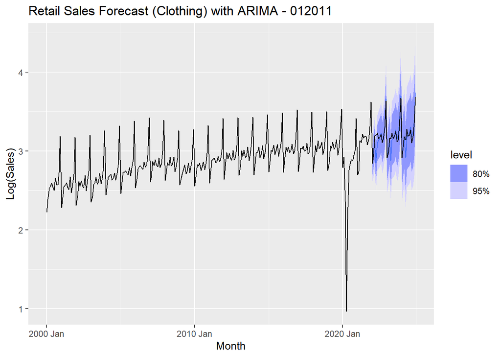

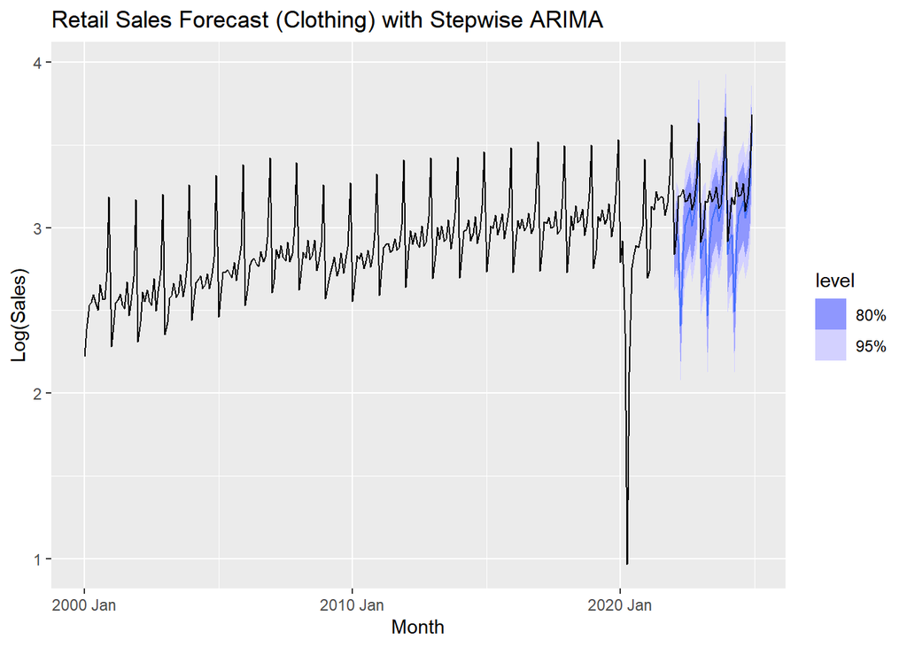

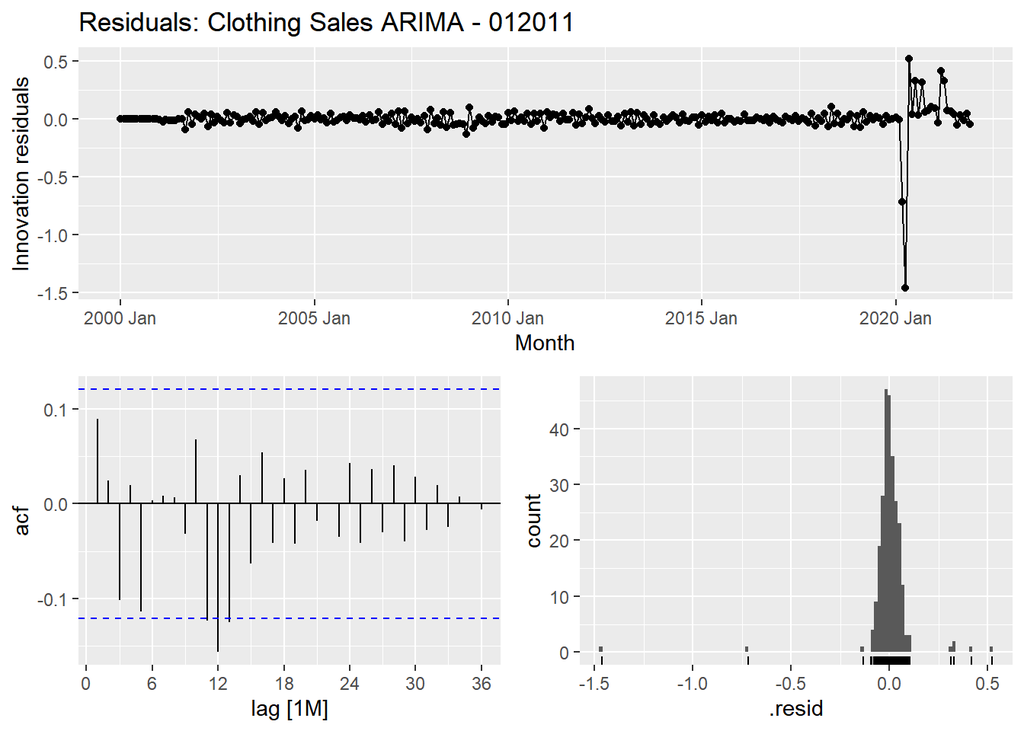

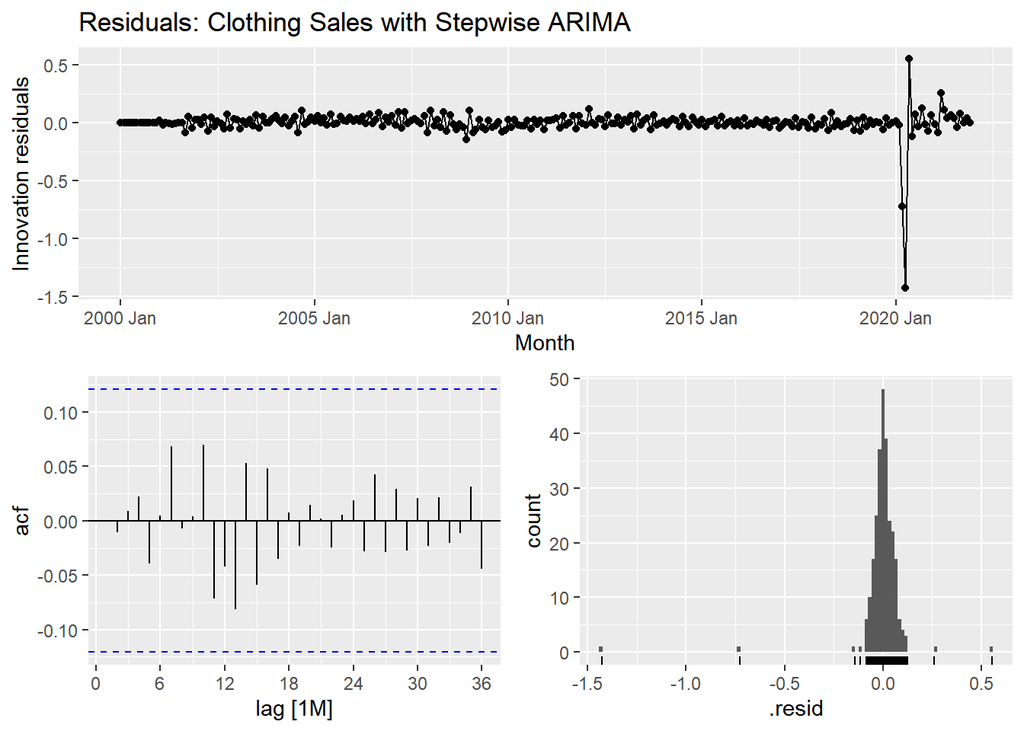

```
# A tibble: 4 × 5
  .model      .type      RMSE    MAE  MAPE
  <chr>       <chr>     <dbl>  <dbl> <dbl>
1 arima012011 Training 0.120  0.0453  1.99
2 stepwise    Training 0.114  0.0443  1.96
3 arima012011 Test     0.0954 0.0601  1.88
4 stepwise    Test     0.250  0.169   5.28
```

```
# A tibble: 2 × 3
  .model      lb_stat lb_pvalue
  <chr>         <dbl>     <dbl>
1 arima012011    8.74     0.365
2 stepwise       1.91     0.862
```

To assess the reliability of the top two clothing sales forecasting models, arima012011 (standard ARIMA) and stepwise ARIMA, I examined their residual behavior and conducted Ljung-Box tests.

Residual Behavior:

- Residuals from both models are centered around zero, suggesting unbiased forecasts.
- The stepwise model shows smaller residual spikes and tighter dispersion, indicating more stable forecasts.
- Histograms for both models exhibit approximately bell-shaped and symmetric distributions, aligning with the assumption of normality.

Autocorrelation (ACF):

- ACF plots for stepwise ARIMA indicate minimal autocorrelation, with most lags falling within the 95% confidence bounds.
- arima012011 also shows limited autocorrelation, suggesting well-fitted residuals.

Ljung-Box Test (lag = 8):

- arima012011: p-value = 0.365 — Fail to reject the null hypothesis; residuals resemble white noise.
- stepwise: p-value = 0.862 — Strong indication of white noise, confirming minimal residual autocorrelation.

Both stepwise and arima012011 passes the white noise test.

### Furniture and Home Furnishings Stores

#### Train - Test Split

I split the dataset into training and test sets. All data before January 2022 was used for training, while data from January 2022 onwards was reserved for testing. This setup allows for an honest evaluation of the forecasting models’ ability to generalize.

I also visualized the training data across the three variables to observe any discrepancies in trends and seasonality, which helped validate the relationships among these features before fitting time series models.

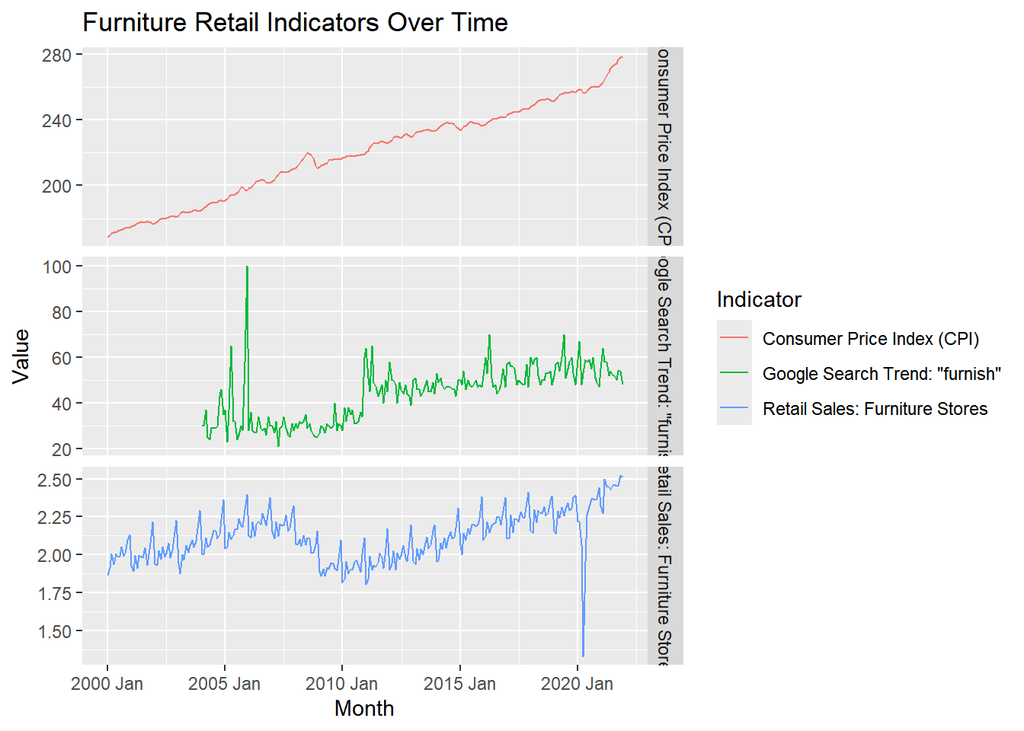

Retail Sales exhibit strong seasonality with an upward trend, sharply rising after pandemic.

#### Model Fitting

```
# A mable: 10 x 2
# Key:     Model name [10]
   `Model name`                                   Orders
   <chr>                                         <model>
 1 fourier6                                       <TSLM>
 2 ets                                     <ETS(A,Ad,A)>
 3 arima012011                 <ARIMA(0,1,2)(0,1,1)[12]>
 4 arima210011                 <ARIMA(2,1,0)(0,1,1)[12]>
 5 arima210110                 <ARIMA(2,1,0)(1,1,0)[12]>
 6 stepwise                    <ARIMA(1,0,2)(0,1,1)[12]>
 7 arima1                      <ARIMA(1,0,2)(1,1,1)[12]>
 8 arimax_cpi     <LM w/ ARIMA(2,0,2)(0,1,2)[12] errors>
 9 arimax_google  <LM w/ ARIMA(0,1,0)(1,0,0)[12] errors>
10 arima_fourier6            <LM w/ ARIMA(0,1,2) errors>
```

##### AIC Comparison

```
# A tibble: 10 × 6
   .model          sigma2 log_lik     AIC    AICc    BIC
   <chr>            <dbl>   <dbl>   <dbl>   <dbl>  <dbl>
 1 fourier6       0.0154    183.  -1087.  -1085.  -1037.
 2 arima_fourier6 0.00398   360.   -692.   -690.   -642.
 3 arimax_cpi     0.00419   329.   -642.   -642.   -614.
 4 arima1         0.00426   326.   -640.   -640.   -619.
 5 stepwise       0.00426   324.   -639.   -639.   -621.
 6 arima012011    0.00427   322.   -635.   -635.   -621.
 7 arima210011    0.00449   316.   -623.   -623.   -609.
 8 arima210110    0.00506   303.   -598.   -598.   -584.
 9 arimax_google  0.00752   197.   -388.   -388.   -378.
10 ets            0.00476   -21.4    78.8    81.6   143.
```

I fitted a combination of models, including ARIMA variants, ETS, Fourier-based regression, and ARIMA models with external regressors like CPI and Google Trends for “furnish.”

###### Forecasts: Top 6 Models Ranked by AICc

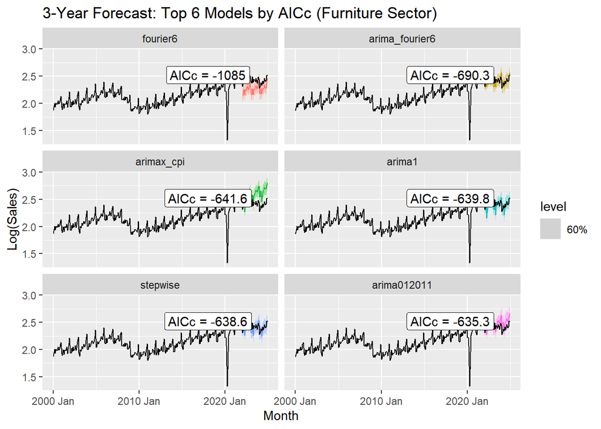

##### Training Data RMSE

```
# A tibble: 10 × 5
   .model         .type      RMSE    MAE  MAPE
   <chr>          <chr>     <dbl>  <dbl> <dbl>
 1 arima_fourier6 Training 0.0614 0.0322  1.59
 2 arimax_cpi     Training 0.0624 0.0331  1.63
 3 arima1         Training 0.0631 0.0333  1.64
 4 stepwise       Training 0.0633 0.0324  1.59
 5 arima012011    Training 0.0634 0.0320  1.58
 6 arima210011    Training 0.0650 0.0332  1.63
 7 ets            Training 0.0667 0.0332  1.64
 8 arima210110    Training 0.0690 0.0388  1.89
 9 arimax_google  Training 0.0953 0.0505  2.45
10 fourier6       Training 0.121  0.0928  4.50
```

I evaluated all models based on their training RMSE to assess their fit to the historical furniture sales data:

- arima_fourier6 had the lowest RMSE (0.061), demonstrating that incorporating seasonal patterns effectively captures fluctuations in furniture sales.
- arimax_cpi (0.062) closely followed, indicating that CPI provides useful economic context in this category.
- arima1 and stepwise performed similarly (~0.063 RMSE), showing that standard ARIMA structures still provide reliable fits.
- ETS had slightly higher RMSE (0.067), suggesting it struggles to handle more complex patterns.
- arimax_google performed poorly (0.095 RMSE), indicating that Google Trends data for “furnish” may not align well with actual sales.
- fourier6 was the weakest (0.121 RMSE), lacking ARIMA’s ability to capture both seasonal and non-seasonal patterns.

Incorporating seasonal structures and economic indicators (CPI) proved effective in improving model fit for furniture sales, whereas Google Trends offered minimal predictive value.

###### Forecasts: Top 6 Models Ranked by Training Data RMSE

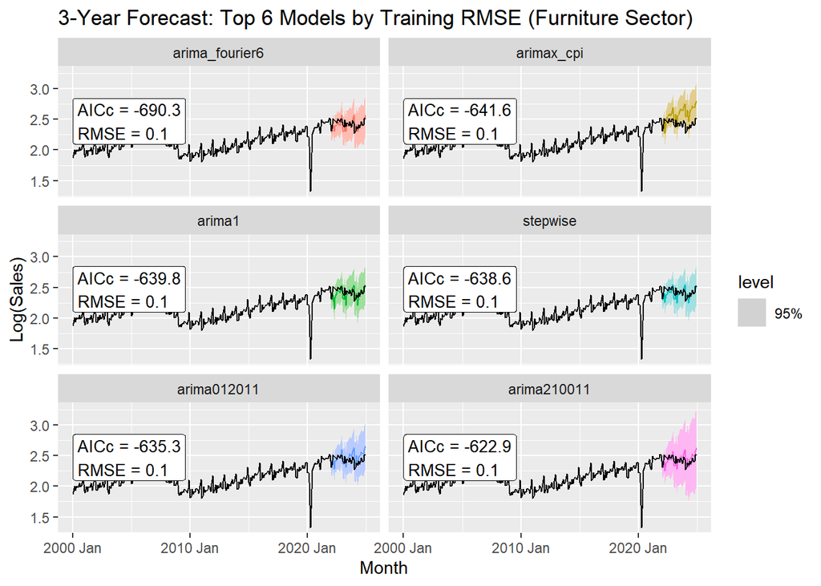

##### Test Data RMSE

```
# A tibble: 10 × 5
   .model         .type   RMSE    MAE  MAPE
   <chr>          <chr>  <dbl>  <dbl> <dbl>
 1 arima_fourier6 Test  0.0600 0.0463  1.89
 2 ets            Test  0.0603 0.0466  1.91
 3 stepwise       Test  0.0665 0.0489  2.01
 4 arima210011    Test  0.0790 0.0658  2.71
 5 arima1         Test  0.0855 0.0600  2.47
 6 arima012011    Test  0.0901 0.0728  3.00
 7 arimax_google  Test  0.141  0.124   5.16
 8 fourier6       Test  0.170  0.158   6.50
 9 arimax_cpi     Test  0.194  0.170   7.03
10 arima210110    Test  0.206  0.149   6.14
```

Overall, Fourier-enhanced ARIMA (arima_fourier6) maintained the best test performance, reinforcing its capacity to handle seasonal patterns effectively in furniture sales forecasting.

###### Forecasts: Top 6 Models Ranked by Test Data RMSE

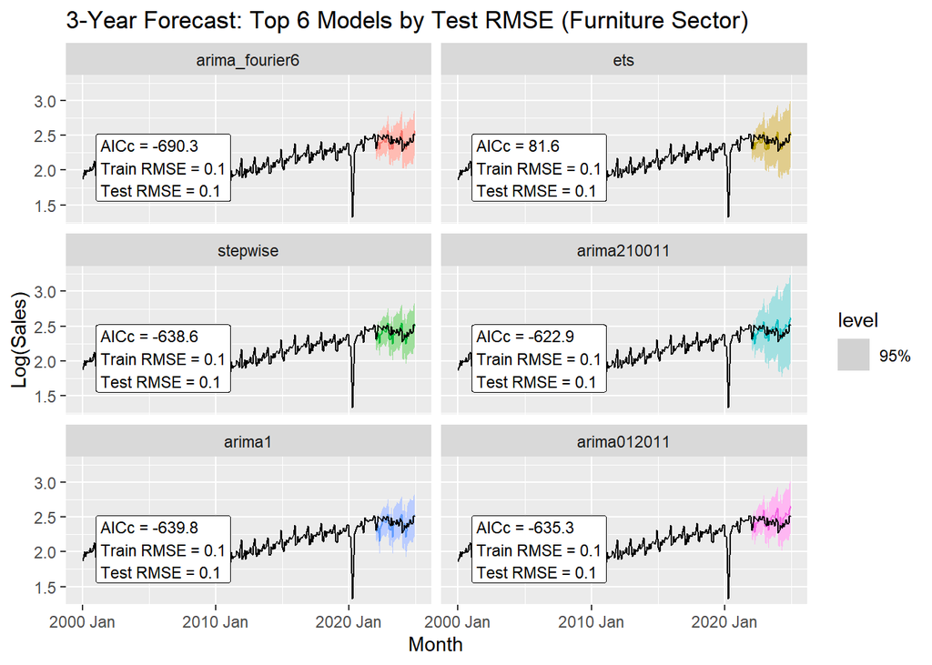

#### Evaluation of ARIMA Models

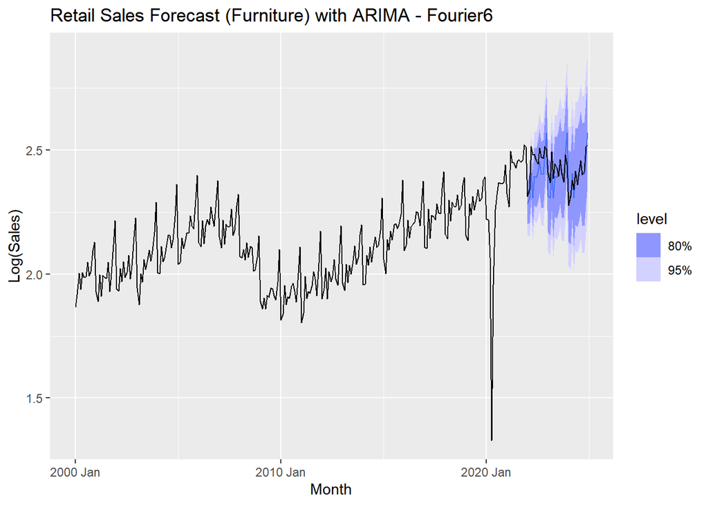

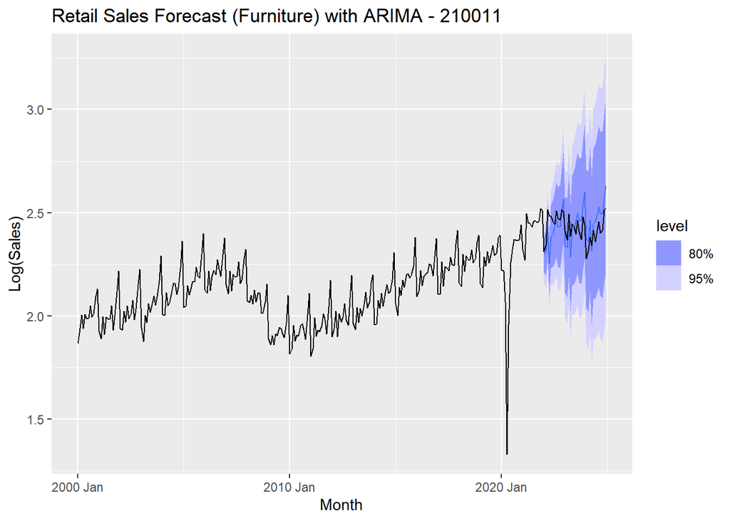

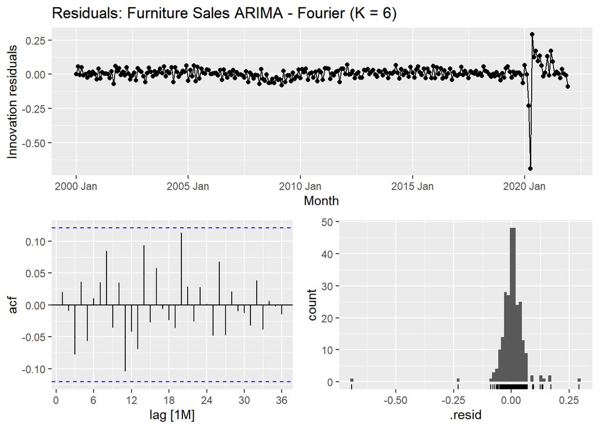

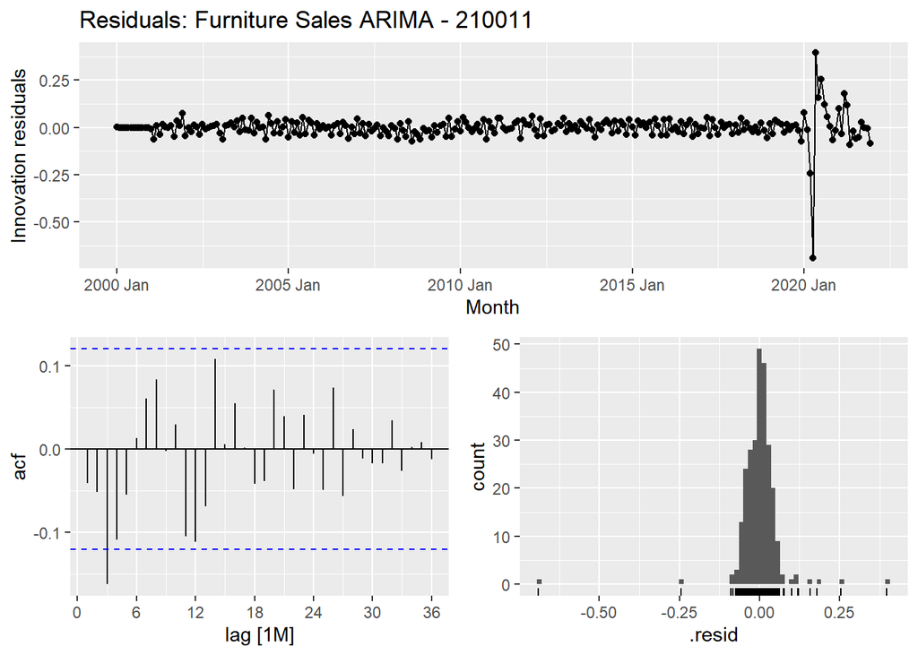

```
# A tibble: 4 × 5
  .model         .type      RMSE    MAE  MAPE
  <chr>          <chr>     <dbl>  <dbl> <dbl>
1 arima_fourier6 Training 0.0614 0.0322  1.59
2 arima210011    Training 0.0650 0.0332  1.63
3 arima_fourier6 Test     0.0600 0.0463  1.89
4 arima210011    Test     0.0790 0.0658  2.71
```

```
# A tibble: 2 × 3
  .model         lb_stat lb_pvalue
  <chr>            <dbl>     <dbl>
1 arima_fourier6    5.31   0.724
2 arima210011      15.3    0.00925
```

## Key Findings

Retail Trade & Food Services:

- ARIMA (210011) emerged as the best model, demonstrating consistent performance in both AICc and RMSE evaluations. Google Trends (“restaurants”) underperformed, indicating that consumer search behavior may not strongly align with sales patterns in this sector.

Clothing Stores:

Furniture & Home Furnishings Stores:

- ARIMA with Fourier terms was the top model, effectively capturing seasonal patterns and outperforming both CPI and Google Trends (“furnish”). External signals provided limited value, indicating that furniture sales are less driven by immediate consumer search behavior.

CPI & Google Trends:

## Conclusion

The analysis reveals that forecasting accuracy is contingent upon sector dynamics and the predictive power of external signals. While ARIMA models with Fourier terms effectively captured seasonality in stable categories like furniture, traditional ARIMA configurations without external regressors provided more reliable forecasts for retail and clothing sectors.

Despite initial assumptions, Google Trends data did not significantly improve forecasting accuracy across most categories, suggesting that search interest may not directly correlate with sales in these sectors. CPI showed moderate predictive power but struggled to generalize in test data, indicating potential overfitting to historical trends.

Incorporating external data sources requires careful consideration of domain-specific behavior. Future analyses should focus on identifying more targeted external signals, refining model selection, and exploring hybrid approaches to optimize forecasting performance.

## Limitations and Next Steps

- Future work could include more granular data (e.g., weekly sales).
- Explore VAR models or machine learning methods.
- Expand Google Trends coverage to include product-level terms or broader categories.